# Untitled

T13_Wed_kable

5/24/2021

The Average Freedom to Make Life Choices Score by Region

| Region | Average Score |
| --- | --- |
| Southeast Asia | 0.9126666 |
| North America and ANZ | 0.9070455 |
| Western Europe | 0.8549933 |
| Latin America and Caribbean | 0.8306836 |
| Commonwealth of Independent States | 0.7840038 |
| South Asia | 0.7718054 |
| Central and Eastern Europe | 0.7702710 |
| East Asia | 0.7610266 |
| Sub-Saharan Africa | 0.7197015 |
| Middle East and North Africa | 0.7101706 |

The above table @ref:(tab:tabfree) is the average “freedom to make life choices” score among all the regions. We divided them into three groups by the average score greater than 8.0, 0.75-0.80, and lower than 0.75.

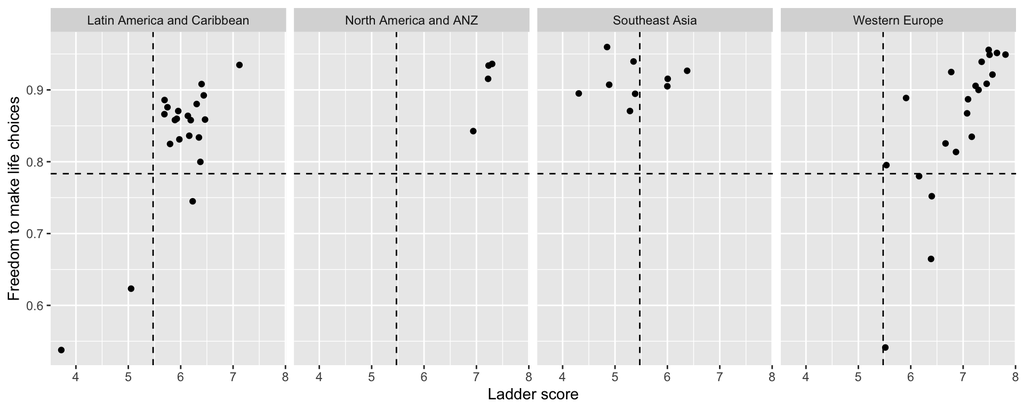

The Group of High Freedom to Make Life Choices Score

As the figure @ref(fig:freeh) above, in the group of the “Freedom to make life choices” score is higher than 8.0, the ladder scores in Latin America and Caribbean, North America and ANZ, Western Europe are comparably high as well. Specifically, most of the points in these three rigions are on the right of the average line. However, in Southeast Asia, the points surrounding the average line represent the ladder scores are not as high as the others.

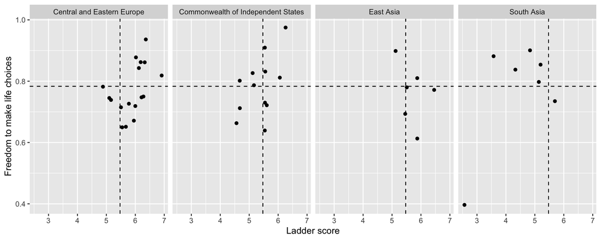

The Group of Middle Freedom to Make Life Choices Score

The above figure @ref(fig:freem) is the group of regions with middle “Freedom to make life choices” score of 0.75-0.80. The distribution of the points is generally surrounding the average line. However, in South Asia, most of the points are lower than the average.

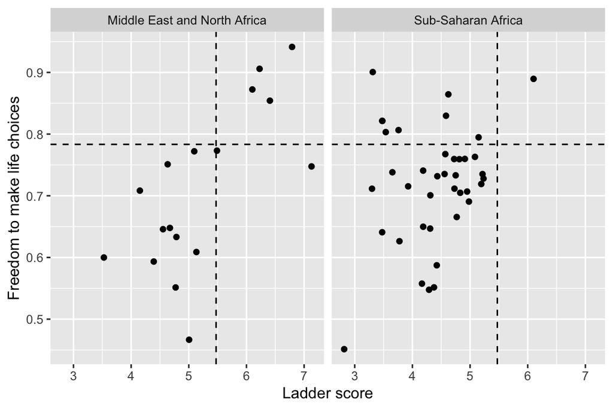

The Group of Low Freedom to Make Life Choices Score

From the above figure @ref(fig:freel), in the low “Freedom to make life choices” score, which is less than 0.75, a tremendous amount of the points of Sub-Saharan Africa are on the left of the average line. However, the points are scattered evenly from high to low in the Middle East and North Africa.

*In general, the ladder score is related to the “Freedom to make life choices” score in most of the regions, except Southeast Asia, and Middle East and North Africa.*

The Average Generosity Score by Region

| Region | Average Score |
| --- | --- |
| North America and ANZ | 0.1641802 |
| Southeast Asia | 0.1618698 |
| Western Europe | 0.0389232 |
| South Asia | 0.0351059 |
| Sub-Saharan Africa | 0.0023831 |
| Commonwealth of Independent States | -0.0412847 |
| East Asia | -0.0519775 |
| Latin America and Caribbean | -0.0719013 |
| Middle East and North Africa | -0.0844265 |
| Central and Eastern Europe | -0.1027124 |

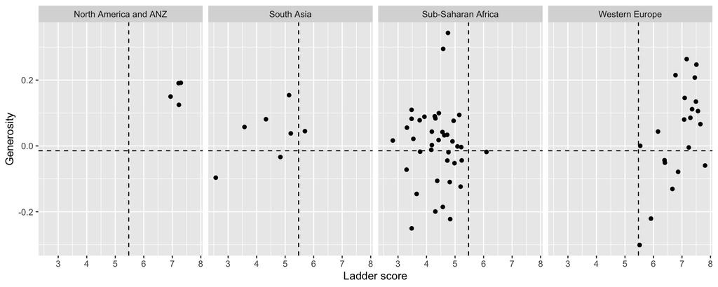

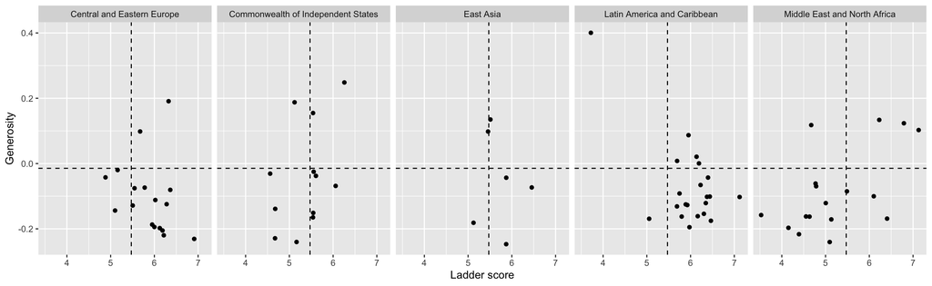

*In general, the generosity score does not show a relationship with the ladder score.*

The Perceptions of Corruption Score by Region

| Region | Average Score |
| --- | --- |
| Central and Eastern Europe | 0.8508587 |
| Latin America and Caribbean | 0.8015262 |
| South Asia | 0.7906557 |
| Sub-Saharan Africa | 0.7704044 |
| Middle East and North Africa | 0.7615096 |
| Commonwealth of Independent States | 0.7463870 |
| Southeast Asia | 0.7049204 |
| East Asia | 0.7022663 |
| Western Europe | 0.5287299 |
| North America and ANZ | 0.4317167 |

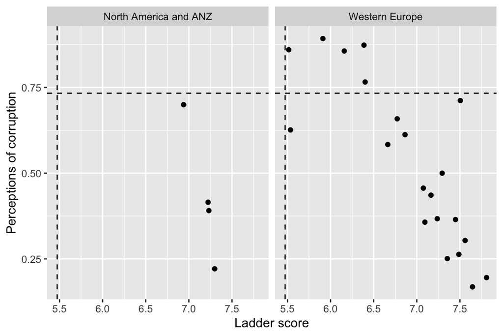

The Group of Low Perceptions of Corruption Score

From the figure @ref(fig:corl), in the group of low “perceptions of corruption” scores with less than 0.70, surprisingly, all the points are at the right of the average ladder score line. This means that if the region has low “perceptions of corruption” scores, the ladder score would be high.

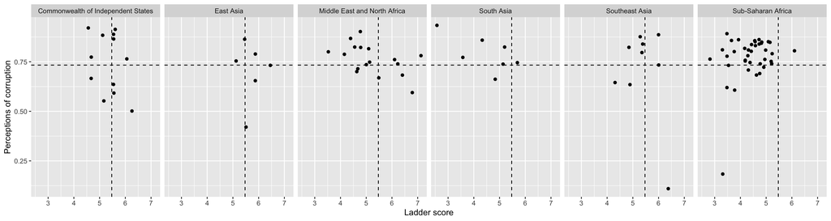

The Group of Middle Perceptions of Corruption Score

From the figure @ref(fig:corm), in the group of middle “perceptions of corruption” scores with between 0.70 and 0.80, except South Asia and Sub-Saharan Africa shows lower ladder score, the other regions all indicate a middle ladder score.

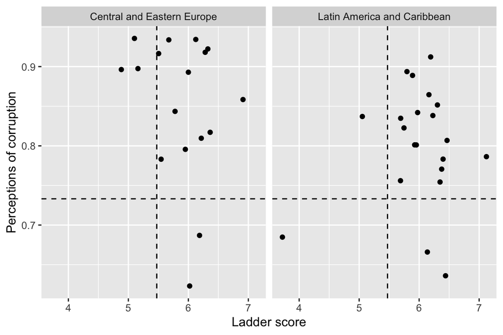

The Group of High Perceptions of Corruption Score

The above figure @ref(fig:corh) is the group of regions with high “perceptions of corruption” scores greater than 0.80. In Central and Eastern Europe, and Latin America and Caribbean, most of the points are on the right of the average line. This means, the region with high “perceptions of corruption” scores could lead to a comparably high ladder score.

*In conclusion, as for the “perceptions of corruption” score, the lowest and the highest four regions all have a high ladder score. Most of the regions in the middle score groups show the middle ladder score.*